# Insights Report

#### WeRateDogs is a Twitter account that rates people's dogs with a humorous comment about the dog. This is a very active account, reaching 4 million followers and even receiving international media coverage. Given this, I thought it would be interesting to take a closer look at what's going there.

#### The first thing that caught my attention was the fact that people seem to be more active on the Twitter app for their phone. We could assume they go into Twitter when they are going from one place to another, or while they are waiting, for example. People don't seem to be as active on Twitter on their website, despite the fact that a lot of people are sitting in front of a computer for a significative amount of time.

#### The second thing worth highlighting is that people like naming their dogs with person's names. From the tweets, I could observe that Charlie, Cooper and Dave seem to be the most popular names for dogs. It seems people want to give easy to remember names to their dogs, instead of being creative.

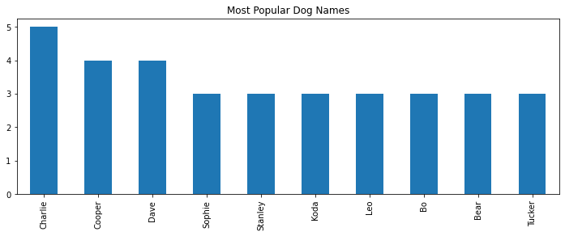

#### Finally, and perhaps the most interesting piece of information to me, is the fact that like and retweet may not be correlated. From looking at the top 3 favorite tweets and comparing those to the top 3 retweets, they don't match completely. In fact, only the first top favorite and most retweeted tweet match. This could be telling us that even though people might like something, that doesn't necessarily mean it's always something worth sharing with others.